# FN1 protein / Fibronectin

Fold-switch pair **3m7pA_3ejhA** — **3m7pA** vs **3ejhA**

Homo sapiens

## Figure 1: Phylogenetic tree with per-cluster fold-preference heatmap.

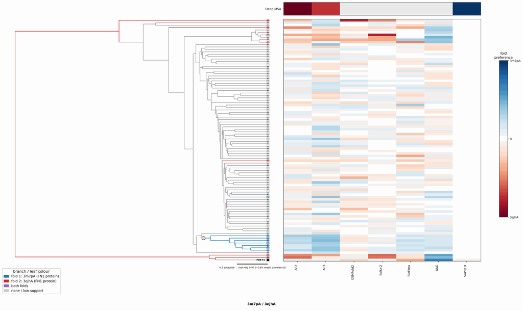

## Figure 2: Aligned overlay (both folds superposed)

The single fold-switching chain of each fold superposed by TM-align; waters hidden, any ligand shown as green sticks. Grey = structurally conserved core, colour = divergent (fold-switching) region.

3m7pA (FN1 protein / Fibronectin) · monomer3ejhA (FN1 protein / Fibronectin) · dimerLigand 12P|NAG (bound to 3m7pA), Ligand HYP|NAG (bound to 3ejhA)

TM-score: 0.499 · Trigger class: mutation

Aligned overlay

Loading...

## Figure 3: The two folds, side by side

Each fold is coloured by per-residue Cα deviation between the two superposed structures: grey ≈ conserved core, full colour = structurally divergent (fold-switching) region.

3m7pA (FN1 protein / Fibronectin)

3ejhA (FN1 protein / Fibronectin)

0 Å5≥10 Å

3m7pA (FN1 protein / Fibronectin)

Loading...

3ejhA (FN1 protein / Fibronectin)

Loading...

## Figure 4: Best-cluster predicted contact maps over the two true folds.

Predicted contact maps (MSA-Transformer) for the clusters best matching each fold, over the true contacts of fold 1 (upper triangle) and fold 2 (lower). Divergent contacts between clusters are the contact-level signature of fold-switching.

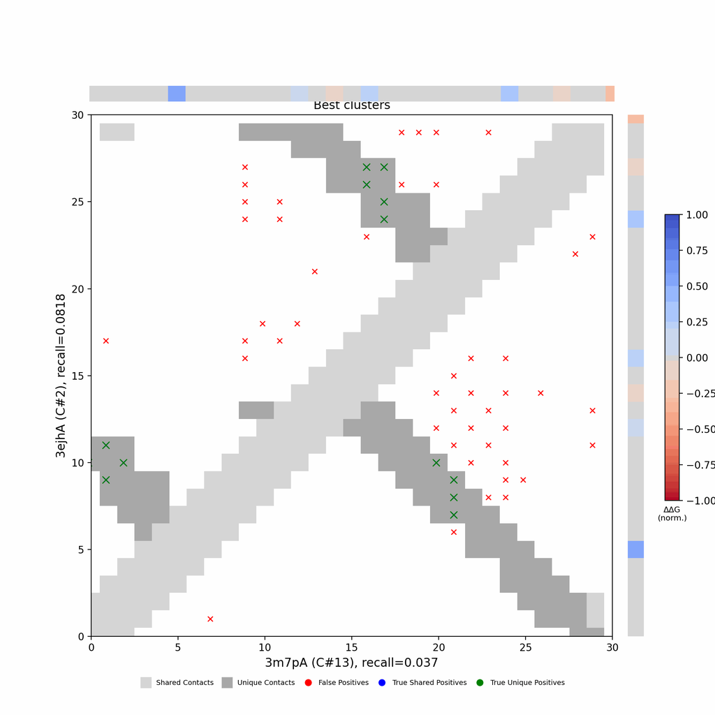

## Figure 5: Per-residue ΔΔG fold-preference contribution

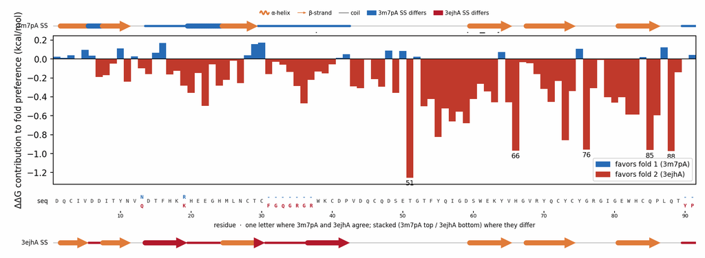

**More figures**

## Figure 6: Deep-MSA contact map panel / Best clusters contact map panel

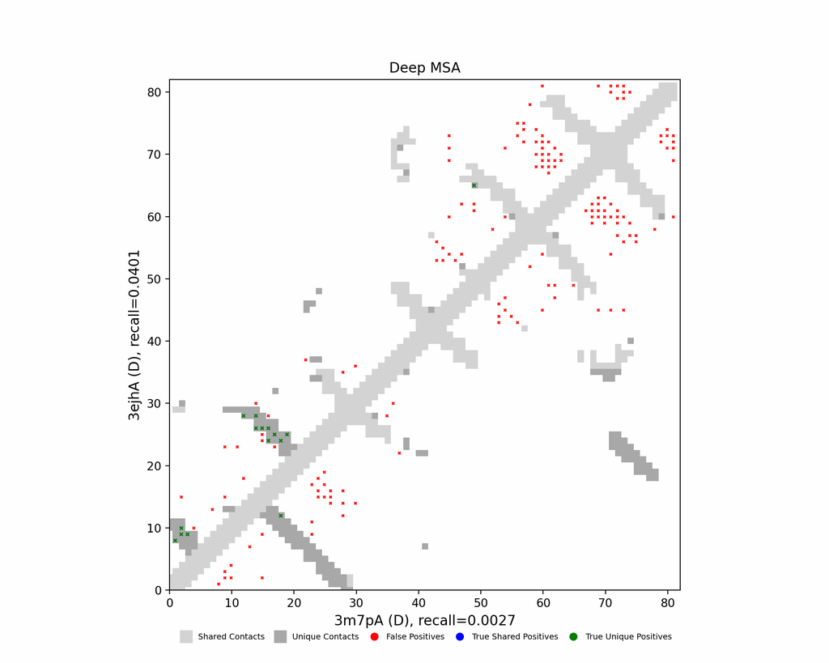

Deep-MSA contact map panel

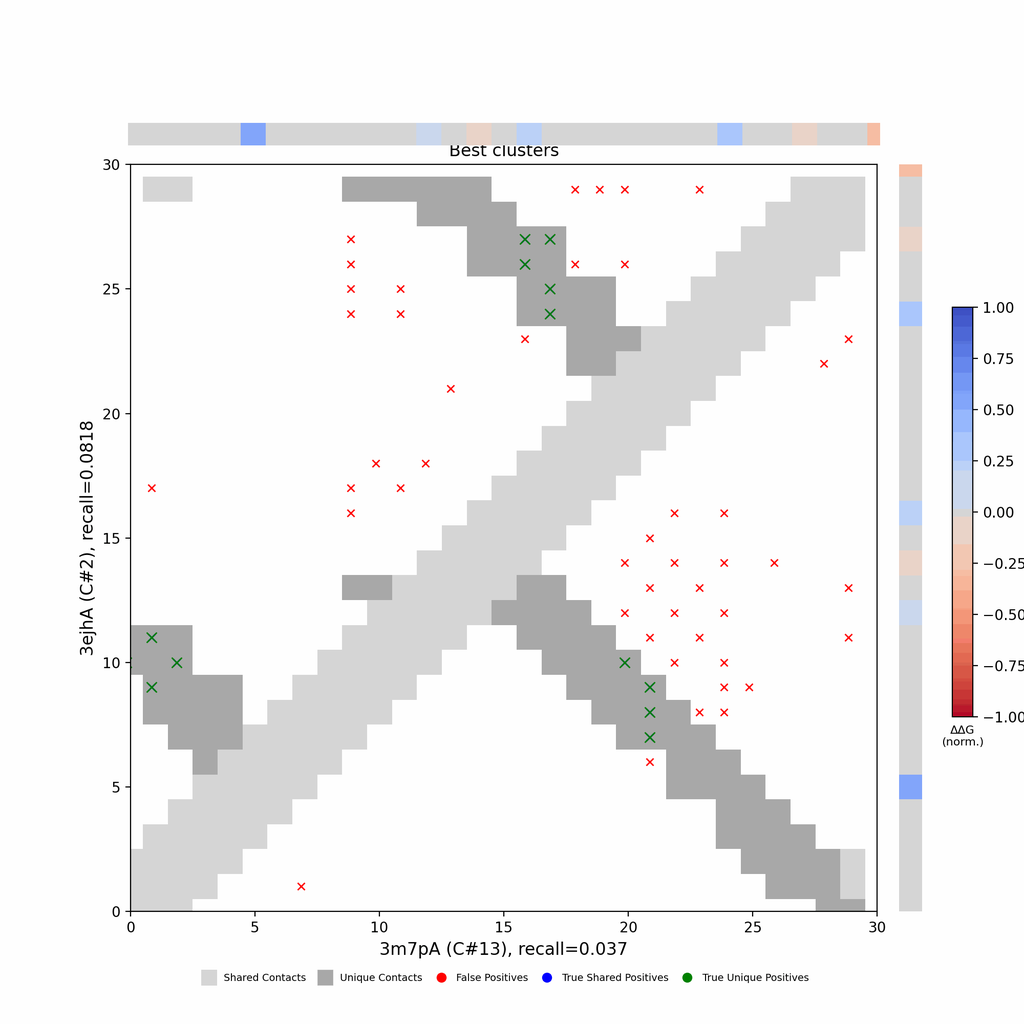

Best clusters contact map panel

## Figure 7: All clusters contact-map mosaic (small multiples).

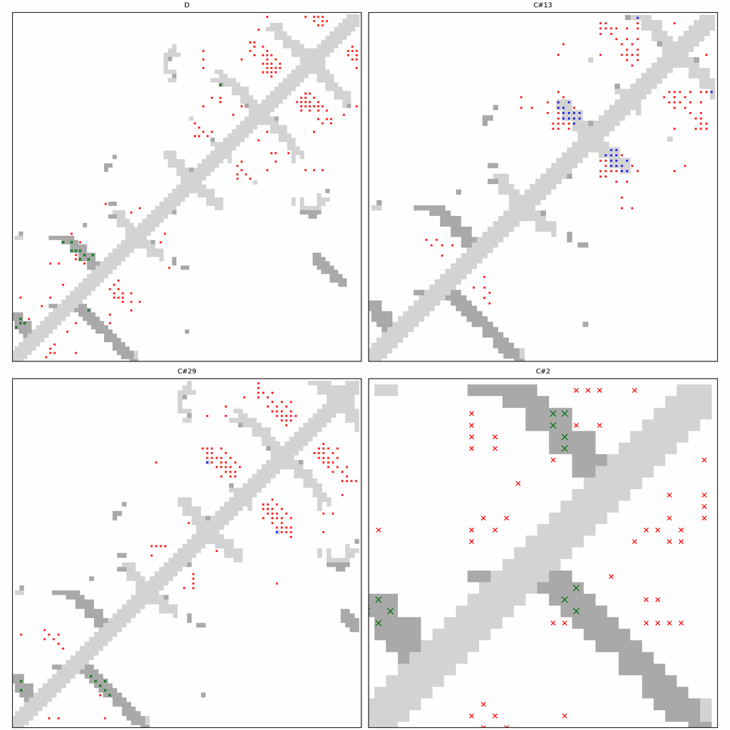

## Figure 8: Phylo null: tree with shuffled cluster fold labels.

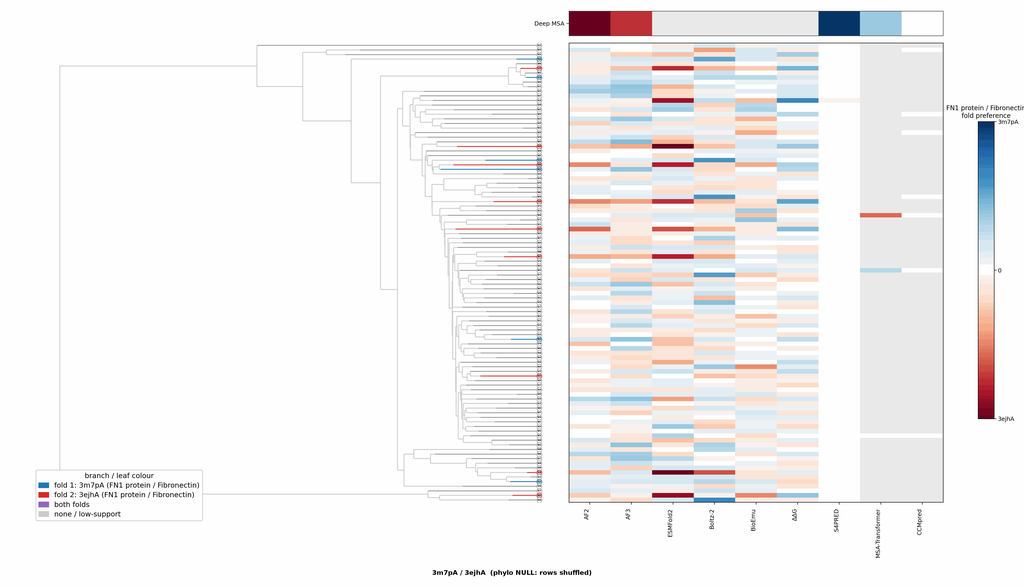

## Cluster metrics table

Per-cluster metrics underlying the figures above.

| cluster | n | neff | AF2_TM1 | AF2_TM2 | AF3_TM1 | AF3_TM2 | RE-MSAT-COM | RE-MSAT1 | RE-MSAT2 | ESM_SEQIDS | ESM_TM1 | ESM_TM2 | ΔΔG_Bias | ΔΔG_Bias_std | ΔΔG_frac_F1 | Boltz2_pref | S4PRED_pref | CCMpred_pref | BioEmu_pref |
| --- | --- | --- | --- | --- | --- | --- | --- | --- | --- | --- | --- | --- | --- | --- | --- | --- | --- | --- | --- |
| Deep | - | - | 0.38 | 0.93 | 0.38 | 0.79 | 0.37 | 0.19 | 0.28 | - | - | - | - | - | - | - | 0.07 | 0.0 | - |
| 000 | 198.0 | 33.0 | 0.27 | 0.49 | 0.3 | 0.7 | - | 0.11 | - | 001; 001; 008; 007; 007; 008; 003; 003; 010; 010 | 0.28 ± 0.02 | 0.38 ± 0.07 | -51.61 | 42.84 | 0.0 | -0.13 | 0.07 | 0.0 | -0.16 |
| 001 | 129.0 | 118.0 | 0.31 | 0.63 | 0.3 | 0.51 | - | 0.1 | - | 002; 002; 001; 001; 008; 008; 005; 005; 003; 007 | 0.32 ± 0.06 | 0.65 ± 0.19 | -67.62 | 37.26 | 0.0 | -0.14 | 0.07 | 0.0 | -0.14 |
| 002 | 104.0 | 58.0 | 0.3 | 0.53 | 0.32 | 0.73 | - | 0.04 | - | 001; 002; 002; 001; 008; 008; 005; 007; 003; 003 | 0.29 ± 0.03 | 0.54 ± 0.21 | -73.16 | 24.14 | 0.0 | -0.1 | 0.07 | 0.0 | -0.21 |
| 003 | 104.0 | 67.0 | 0.31 | 0.48 | 0.27 | 0.62 | - | 0.01 | - | 005; 005; 007; 007; 010; 010; 003; 003; 004; 004 | 0.28 ± 0.03 | 0.31 ± 0.03 | -84.49 | 16.75 | 0.0 | -0.2 | 0.07 | 0.0 | -0.11 |
| 004 | 92.0 | 80.0 | 0.27 | 0.5 | 0.26 | 0.53 | - | 0.15 | - | 002; 002; 003; 003; 010; 004; 006; 006; 004; 009 | 0.26 ± 0.01 | 0.33 ± 0.04 | -89.1 | 23.47 | 0.0 | -0.11 | 0.07 | 0.0 | -0.16 |
| 005 | 88.0 | 84.0 | 0.28 | 0.55 | 0.34 | 0.63 | - | 0.06 | - | 008; 008; 002; 002; 007; 004; 007; 004; 005; 005 | 0.25 ± 0.01 | 0.31 ± 0.03 | -87.7 | 14.75 | 0.0 | -0.12 | 0.07 | 0.0 | -0.24 |
| 006 | 81.0 | 61.0 | 0.34 | 0.55 | 0.37 | 0.66 | - | 0.06 | - | 002; 002; 003; 003; 008; 008; 001; 001; 010; 010 | 0.31 ± 0.04 | 0.48 ± 0.17 | -77.73 | 18.88 | 0.0 | -0.08 | 0.07 | 0.0 | -0.22 |
| 007 | 79.0 | 32.0 | 0.3 | 0.74 | 0.25 | 0.78 | 0.0 | 0.16 | 0.01 | - | - | - | -61.51 | 22.5 | 0.0 | -0.55 | 0.07 | - | -0.17 |
| 008 | 78.0 | 46.0 | 0.28 | 0.55 | 0.32 | 0.65 | - | 0.04 | - | - | - | - | -79.41 | 14.38 | 0.0 | -0.1 | 0.07 | - | -0.12 |
| 009 | 73.0 | 4.0 | 0.23 | 0.62 | 0.25 | 0.79 | 0.0 | 0.01 | 0.0 | - | - | - | -39.94 | 9.78 | 0.0 | -0.32 | 0.07 | - | -0.05 |
| 010 | 70.0 | 11.0 | 0.18 | 0.26 | 0.23 | 0.34 | - | 0.04 | - | - | - | - | -60.0 | 4.9 | 0.0 | -0.08 | 0.07 | - | -0.13 |
| 011 | 67.0 | 5.0 | 0.2 | 0.28 | 0.23 | 0.33 | - | 0.0 | - | - | - | - | -63.06 | 5.88 | 0.0 | -0.06 | 0.07 | - | -0.1 |
| 012 | 66.0 | 58.0 | 0.32 | 0.51 | 0.3 | 0.53 | - | 0.02 | - | - | - | - | -91.69 | 20.5 | 0.0 | -0.13 | 0.07 | - | -0.11 |
| 013 | 64.0 | 52.0 | 0.31 | 0.52 | 0.29 | 0.57 | - | 0.16 | - | - | - | - | -88.84 | 17.74 | 0.0 | -0.12 | 0.07 | - | -0.2 |
| 014 | 61.0 | 2.0 | 0.31 | 0.51 | 0.28 | 0.63 | 0.0 | 0.01 | 0.0 | - | - | - | -13.03 | 12.35 | 0.0 | -0.12 | 0.06 | - | -0.28 |
| 015 | 60.0 | 37.0 | 0.33 | 0.51 | 0.31 | 0.52 | - | 0.02 | - | - | - | - | -82.47 | 12.23 | 0.0 | -0.1 | 0.07 | - | -0.21 |
| 016 | 59.0 | 35.0 | 0.28 | 0.51 | 0.28 | 0.55 | - | 0.02 | - | - | - | - | -76.78 | 16.26 | 0.0 | -0.07 | 0.07 | - | -0.16 |
| 017 | 58.0 | 45.0 | 0.26 | 0.48 | 0.29 | 0.51 | - | 0.1 | - | - | - | - | -85.74 | 19.99 | 0.0 | -0.09 | 0.07 | - | -0.17 |
| 018 | 55.0 | 33.0 | 0.26 | 0.65 | 0.38 | 0.62 | 0.09 | 0.02 | 0.18 | - | - | - | -65.59 | 25.34 | 0.0 | -0.38 | 0.07 | - | -0.2 |
| 019 | 54.0 | 6.0 | 0.27 | 0.54 | 0.24 | 0.74 | 0.02 | 0.01 | 0.02 | - | - | - | -31.91 | 11.88 | 0.0 | -0.32 | 0.06 | - | -0.15 |
| 020 | 53.0 | 42.0 | 0.26 | 0.5 | 0.34 | 0.72 | - | 0.09 | - | - | - | - | -85.02 | 10.17 | 0.0 | -0.16 | 0.07 | - | -0.16 |
| 021 | 50.0 | 41.0 | 0.4 | 0.51 | 0.29 | 0.65 | - | 0.04 | - | - | - | - | -89.11 | 15.35 | 0.0 | -0.11 | 0.07 | - | -0.18 |
| 022 | 50.0 | 42.0 | 0.28 | 0.55 | 0.27 | 0.63 | - | 0.03 | - | - | - | - | -86.72 | 18.88 | 0.0 | -0.15 | 0.07 | - | -0.1 |
| 023 | 49.0 | 24.0 | 0.34 | 0.58 | 0.29 | 0.61 | - | 0.06 | - | - | - | - | -70.98 | 14.21 | 0.0 | -0.12 | 0.07 | - | -0.19 |
| 024 | 49.0 | 46.0 | 0.28 | 0.57 | 0.25 | 0.65 | - | 0.02 | - | - | - | - | -67.95 | 17.13 | 0.0 | -0.1 | 0.07 | - | -0.22 |
| 025 | 46.0 | 46.0 | 0.26 | 0.53 | 0.39 | 0.74 | - | 0.01 | - | - | - | - | -85.31 | 12.57 | 0.0 | -0.12 | 0.07 | - | -0.14 |
| 026 | 45.0 | 20.0 | 0.3 | 0.49 | 0.31 | 0.67 | - | 0.06 | - | - | - | - | -86.19 | 13.07 | 0.0 | -0.15 | 0.07 | - | -0.15 |
| 027 | 44.0 | 33.0 | 0.26 | 0.52 | 0.38 | 0.69 | - | 0.08 | - | - | - | - | -96.45 | 20.54 | 0.0 | -0.12 | 0.07 | - | -0.17 |
| 028 | 43.0 | 42.0 | 0.27 | 0.54 | 0.32 | 0.53 | - | 0.13 | - | - | - | - | -84.92 | 11.19 | 0.0 | -0.1 | 0.07 | - | -0.17 |

[output cut: 71 more lines]